# Clinical Data Analysis and Exploratory Study

Kisara & Savindi

2026-02-14

## This notebook presents an exploratory analysis of a clinical data set.The workflow includes data loading, data cleaning and preprocessing,exploratory data analysis (EDA), and interpretation of findings.The results from this analysis provide a foundation for subsequent predictive modeling.

## Contribution Statement

**Kisara:** - Data loading, Data cleaning and preprocessing, exploratory data analysis (EDA), and interpretation. **Savindi:** - Analytical Interpretation,Relationship Between Patient Characteristics and Survival Outcome, Overall Answer to the question ————————————————————————————————————— **Data source:** This study uses publicly available clinical cancer data from the MSK-CHORD 2024 data set. —————————————————————————————————————

## Step 1: Load the Dataset

## Step 2: Data Cleaning and Preprocessing

## Step 3: Exploratory Data Analysis (EDA)

## Step 4: Interpretation

## Step 5: Analytical Interpreation

## Step 6: Relationship Between Patient Characteristics and Survival Outcome

# Load required libraries

```r
library(tidyverse)   # data manipulation and visualization
library(janitor)     # data cleaning utilities
library(here)        # reproducible file paths
```

```r
library(ggplot2)     # plotting
```

# Step 1: Load the Data set

In this step, the raw clinical data set is loaded from the `data/raw` directory. The `here()` package is used to ensure reproducible file paths.

```r
clinical_data <- read_tsv(
  here("data", "raw", "msk_chord_2024_clinical_data.tsv"),
)
```

## Inspections about the data set

```r
glimpse(clinical_data)
```

```
## Rows: 25,040
## Columns: 53
## $ `Study ID`                               <chr> "msk_chord_2024", "msk_chord_…
## $ `Patient ID`                             <chr> "P-0000012", "P-0000012", "P-…
## $ `Sample ID`                              <chr> "P-0000012-T02-IM3", "P-00000…
## $ `Tumor Site: Adrenal Glands (NLP)`       <chr> "No", "No", "No", "No", "No",…
## $ `Tumor Site: Bone (NLP)`                 <chr> "No", "No", "Yes", "Yes", "Ye…
## $ `Cancer Type`                            <chr> "Breast Cancer", "Non-Small C…
## $ `Cancer Type Detailed`                   <chr> "Breast Invasive Ductal Carci…
## $ `Clinical Group`                         <chr> NA, "3B", "1", "4", "2A", "4"…
## $ `Clinical Summary`                       <chr> NA, "Distant", "Localized", "…
## $ `Tumor Site: CNS/Brain (NLP)`            <chr> "No", "No", "Yes", "No", "Yes…
## $ `Current Age`                            <dbl> 68, 68, 45, 68, 53, 43, 54, 7…
## $ `Diagnosis Description`                  <chr> "Breast", "Lung and Bronchus"…
## $ Ethnicity                                <chr> "Non-Spanish; Non-Hispanic", …
```

[output cut: 40 more lines]

```r
colnames(clinical_data)
```

```
##  [1] "Study ID"
##  [2] "Patient ID"
##  [3] "Sample ID"
##  [4] "Tumor Site: Adrenal Glands (NLP)"
##  [5] "Tumor Site: Bone (NLP)"
##  [6] "Cancer Type"
##  [7] "Cancer Type Detailed"
##  [8] "Clinical Group"
##  [9] "Clinical Summary"
## [10] "Tumor Site: CNS/Brain (NLP)"
## [11] "Current Age"
## [12] "Diagnosis Description"
## [13] "Ethnicity"
## [14] "Fraction Genome Altered"
## [15] "Sex"
```

[output cut: 38 more lines]

# Step 2: Data Cleaning and Preprocessing

This step focuses on preparing the data set for analysis by cleaning variable names, selecting relevant columns, and assessing missing values.

## Step 2.1: Clean column names

```r
library(janitor)

clinical_data <- clinical_data %>%
  clean_names()
```

### Why this matters:

- Converts spaces to `_`
- Removes special characters
- Makes variables easier to use in code

## Step 2.2: Check updated column names

```r
colnames(clinical_data)
```

```
##  [1] "study_id"
##  [2] "patient_id"
##  [3] "sample_id"
##  [4] "tumor_site_adrenal_glands_nlp"
##  [5] "tumor_site_bone_nlp"
##  [6] "cancer_type"
##  [7] "cancer_type_detailed"
##  [8] "clinical_group"
##  [9] "clinical_summary"
## [10] "tumor_site_cns_brain_nlp"
## [11] "current_age"
## [12] "diagnosis_description"
## [13] "ethnicity"
## [14] "fraction_genome_altered"
## [15] "sex"
```

[output cut: 38 more lines]

## Step 2.3: Select relevant variables

```r
clinical_clean <- clinical_data %>%
  select(
    study_id,
    patient_id,
    sample_id,
    current_age,
    sex,
    race,
    cancer_type,
    primary_tumor_site,
    stage_highest_recorded,
    overall_survival_months,
    overall_survival_status
  )
```

## Step 2.4: Check missing values

```r
colSums(is.na(clinical_clean))
```

```
##                study_id              patient_id               sample_id
##                       0                       0                       0
##             current_age                     sex                    race
##                       3                       0                       0
##             cancer_type      primary_tumor_site  stage_highest_recorded
##                       0                       0                       0
## overall_survival_months overall_survival_status
##                       0                       0
```

## Step 2.5: Check categorical value consistency

```r
unique(clinical_clean$overall_survival_status)
```

```
## [1] "0:LIVING"   "1:DECEASED"
```

```r
unique(clinical_clean$stage_highest_recorded)
```

```
## [1] "Stage 1-3" "Stage 4"   "Unknown"
```

```r
unique(clinical_clean$sex)
```

```
## [1] "Female"  "Male"    "Unknown"
```

In this step, missing values are handled appropriately, categorical variables are standardized, and data types are corrected to prepare the data set for analysis.

## Step 2.6: Handling missing values

```r
clinical_clean <- clinical_clean %>%
  mutate(
    current_age = ifelse(
      is.na(current_age),
      median(current_age, na.rm = TRUE),
      current_age
    )
  )
```

Missing values in `current_age` were minimal and were imputed using the median to avoid bias from extreme values.

## Step 2.7: Standardize categorical variables

```r
clinical_clean <- clinical_clean %>%
  mutate(
    overall_survival_status = case_when(
      overall_survival_status == "0:LIVING" ~ "Living",
      overall_survival_status == "1:DECEASED" ~ "Deceased",
      TRUE ~ overall_survival_status
    )
  )

# Sex variable (defensive cleaning)
clinical_clean <- clinical_clean %>%
  mutate(
    sex = case_when(
      sex %in% c("Male", "M") ~ "Male",
      sex %in% c("Female", "F") ~ "Female",
      TRUE ~ sex
    )
  )
```

## Step 2.8: Convert data types properly

```r
clinical_clean <- clinical_clean %>%
  mutate(
    current_age = as.numeric(current_age),
    overall_survival_months = as.numeric(overall_survival_months)
  )
```

## Step 2.9: Final Verification

```r
glimpse(clinical_clean)
```

```
## Rows: 25,040
## Columns: 11
## $ study_id                <chr> "msk_chord_2024", "msk_chord_2024", "msk_chord…
## $ patient_id              <chr> "P-0000012", "P-0000012", "P-0000015", "P-0000…
## $ sample_id               <chr> "P-0000012-T02-IM3", "P-0000012-T03-IM3", "P-0…
## $ current_age             <dbl> 68, 68, 45, 68, 53, 43, 54, 71, 83, 50, 70, 46…
## $ sex                     <chr> "Female", "Female", "Female", "Female", "Femal…
## $ race                    <chr> "White", "White", "White", "Other", "White", "…
## $ cancer_type             <chr> "Breast Cancer", "Non-Small Cell Lung Cancer",…
## $ primary_tumor_site      <chr> "Breast", "Lung", "Breast", "Lung", "Breast", …
## $ stage_highest_recorded  <chr> "Stage 1-3", "Stage 1-3", "Stage 1-3", "Stage …
## $ overall_survival_months <dbl> 118.4546647, 118.4546647, 13.9068341, 115.4628…
## $ overall_survival_status <chr> "Living", "Living", "Deceased", "Living", "Dec…
```

```r
colSums(is.na(clinical_clean))
```

```
##                study_id              patient_id               sample_id
##                       0                       0                       0
##             current_age                     sex                    race
##                       0                       0                       0
##             cancer_type      primary_tumor_site  stage_highest_recorded
##                       0                       0                       0
## overall_survival_months overall_survival_status
##                       0                       0
```

After preprocessing, all selected variables contained no missing values,and data types were verified to ensure suitability for analysis.

## Step 2.10: Saving the final cleaned dataset

```r
write_csv(
  clinical_clean,
  here("data", "clean", "clinical_data_clean.csv")
)
```

The data set was cleaned by standardizing column names, selecting relevant variables,handling missing values, correcting data types, and harmonizing categorical variables.The final cleaned data set is used for all downstream analyses. _______________________________________________________________________________________________________________ # Step 3: Exploratory Data Analysis (EDA)

The following exploratory analysis examines key demographic, clinical, and outcome-related variables to identify patterns and distributions within the data set.

**Descriptive Overview**

This section provides an initial overview of the cleaned clinical data set using summary statistics and frequency distributions.

## Step 3.1: Loading the cleaned dataset

```r
clinical_clean <- read_csv(
  here("data", "clean", "clinical_data_clean.csv")
)
```

## Step 3.2: View basic structure

```r
glimpse(clinical_clean)
```

```
## Rows: 25,040
## Columns: 11
## $ study_id                <chr> "msk_chord_2024", "msk_chord_2024", "msk_chord…
## $ patient_id              <chr> "P-0000012", "P-0000012", "P-0000015", "P-0000…
## $ sample_id               <chr> "P-0000012-T02-IM3", "P-0000012-T03-IM3", "P-0…
## $ current_age             <dbl> 68, 68, 45, 68, 53, 43, 54, 71, 83, 50, 70, 46…
## $ sex                     <chr> "Female", "Female", "Female", "Female", "Femal…
## $ race                    <chr> "White", "White", "White", "Other", "White", "…
## $ cancer_type             <chr> "Breast Cancer", "Non-Small Cell Lung Cancer",…
## $ primary_tumor_site      <chr> "Breast", "Lung", "Breast", "Lung", "Breast", …
## $ stage_highest_recorded  <chr> "Stage 1-3", "Stage 1-3", "Stage 1-3", "Stage …
## $ overall_survival_months <dbl> 118.4546647, 118.4546647, 13.9068341, 115.4628…
## $ overall_survival_status <chr> "Living", "Living", "Deceased", "Living", "Dec…
```

## Step 3.3: Summary statistics (numeric + categorical)

```r
summary(clinical_clean)
```

```
##    study_id          patient_id         sample_id          current_age
##  Length:25040       Length:25040       Length:25040       Min.   :10.00
##  Class :character   Class :character   Class :character   1st Qu.:57.00
##  Mode  :character   Mode  :character   Mode  :character   Median :67.00
##                                                           Mean   :65.48
##                                                           3rd Qu.:75.00
##                                                           Max.   :89.00
##      sex                race           cancer_type        primary_tumor_site
##  Length:25040       Length:25040       Length:25040       Length:25040
##  Class :character   Class :character   Class :character   Class :character
##  Mode  :character   Mode  :character   Mode  :character   Mode  :character
##
##
##
##  stage_highest_recorded overall_survival_months overall_survival_status
##  Length:25040           Min.   :  0.03288       Length:25040
##  Class :character       1st Qu.: 11.14519       Class :character
##  Mode  :character       Median : 24.65751       Mode  :character
##                         Mean   : 32.12850
##                         3rd Qu.: 49.18351
##                         Max.   :118.45467
```

## Step 3.4: Frequency tables (key categorical variables)

```r
table(clinical_clean$sex)
```

```
##
##  Female    Male Unknown
##   13923   11114       3
```

```r
table(clinical_clean$overall_survival_status)
```

```
##
## Deceased   Living
##    11346    13694
```

```r
table(clinical_clean$stage_highest_recorded)
```

```
##
## Stage 1-3   Stage 4   Unknown
##     15229      9808         3
```

The descriptive analysis shows the distribution of patient demographics,clinical characteristics, and survival outcomes, providing a foundation for more detailed exploratory analysis.

**Demographic Analysis**

This section explores the demographic characteristics of patients, including age, sex, and race distributions.

## Step 3.5: Age distribution

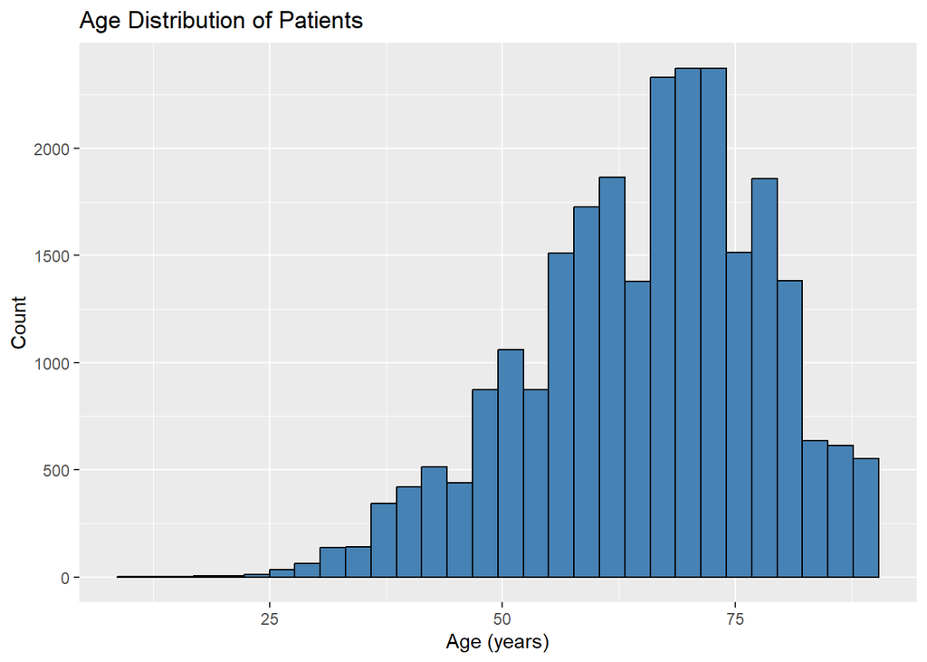

```r
ggplot(clinical_clean, aes(x = current_age)) +
  geom_histogram(bins = 30,fill = "steelblue",color = "black") +
  labs(
    title = "Age Distribution of Patients",
    x = "Age (years)",
    y = "Count"
  )
```

The age distribution shows the spread of patient ages in the data set,highlighting the most common age ranges represented.

## Step 3.6: Sex distribution

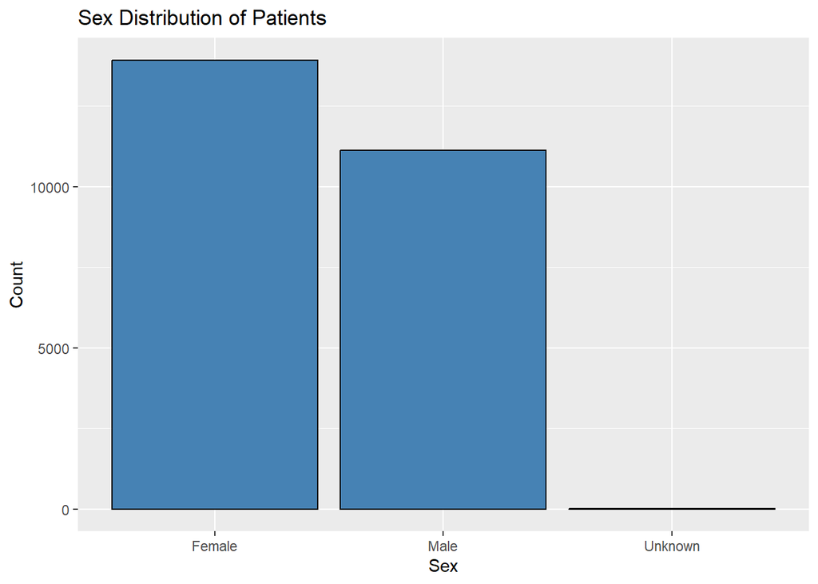

```r
ggplot(clinical_clean, aes(x = sex)) +
  geom_bar(fill = "steelblue",color = "black") +
  labs(
    title = "Sex Distribution of Patients",
    x = "Sex",
    y = "Count"
  )
```

This bar chart illustrates the distribution of patients by sex in the data set.

## Step 3.7: Race distribution

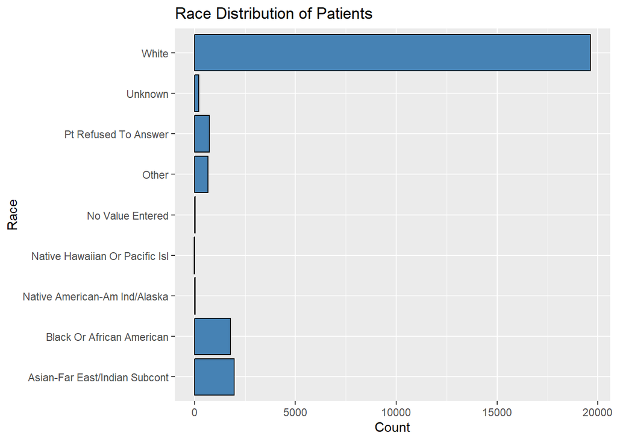

```r
ggplot(clinical_clean, aes(x = race)) +
  geom_bar(fill = "steelblue", color ="black") +
  coord_flip() +
  labs(
    title = "Race Distribution of Patients",
    x = "Race",
    y = "Count"
  )
```

The race distribution highlights the representation of different racial groups,with some categories appearing more frequently than others.

**Clinical Characteristics**

This section explores clinical features of the patients, including cancer type,primary tumor site, and recorded cancer stage.

## Step 3.8: Cancer type distribution

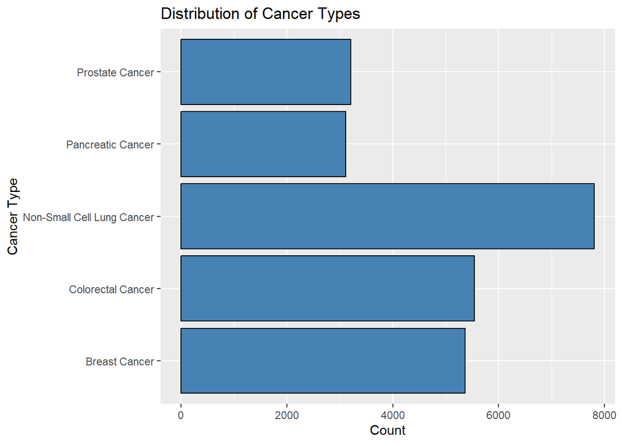

```r
ggplot(clinical_clean, aes(x = cancer_type)) +
  geom_bar(fill = "steelblue", color = "black") +
  coord_flip() +
  labs(
    title = "Distribution of Cancer Types",
    x = "Cancer Type",
    y = "Count"
  )
```

The distribution shows the frequency of different cancer types represented in the data set, indicating which conditions are most commonly observed.

## Step 3.9: Primary tumor site distribution

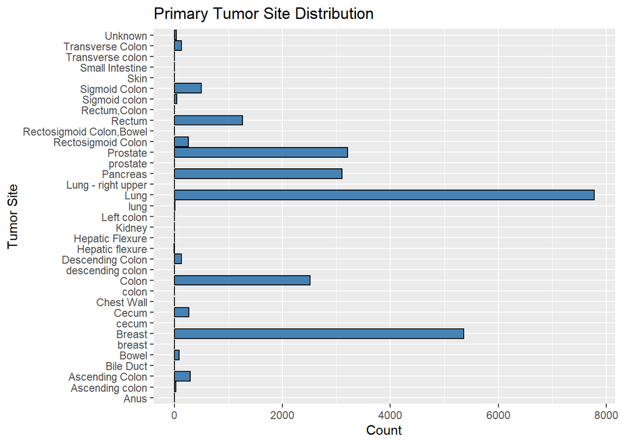

```r
ggplot(clinical_clean, aes(x = primary_tumor_site)) +
  geom_bar(fill="steelblue", color = "black") +
  coord_flip() +
  labs(
    title = "Primary Tumor Site Distribution",
    x = "Tumor Site",
    y = "Count"
  )
```

This plot illustrates the anatomical locations of primary tumors among patients,highlighting the most frequently affected sites.

## Step 3.10: Cancer stage distribution

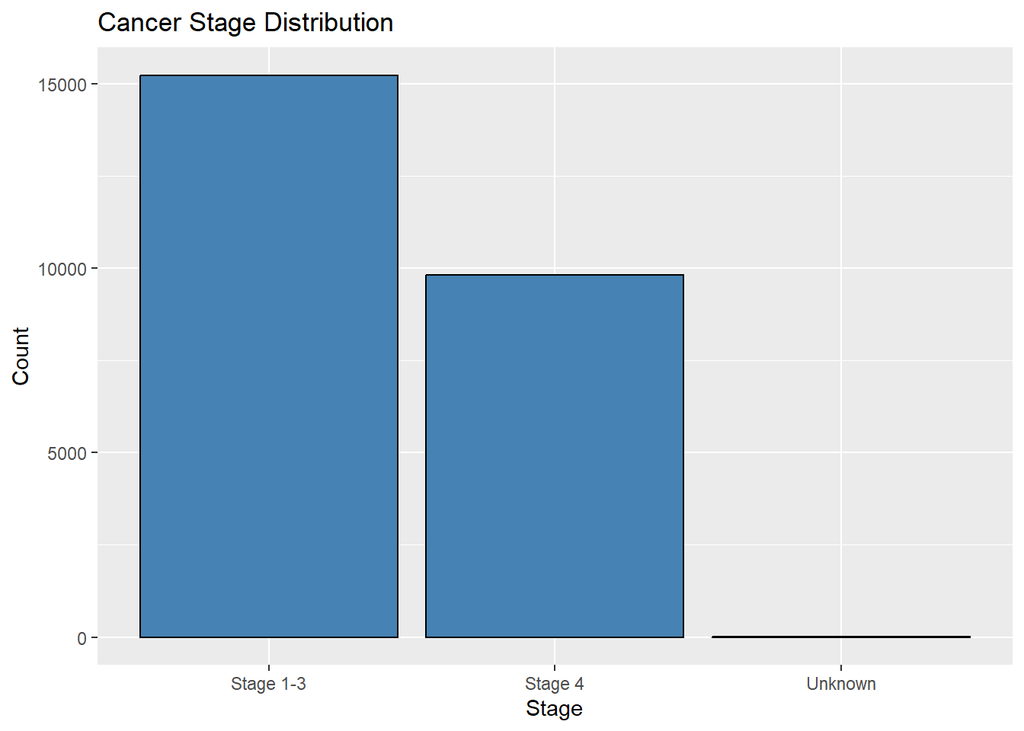

```r
ggplot(clinical_clean, aes(x = stage_highest_recorded)) +
  geom_bar(fill = "steelblue" , color = "black") +
  labs(
    title = "Cancer Stage Distribution",
    x = "Stage",
    y = "Count"
  )
```

The cancer stage distribution provides insight into disease severity at diagnosis,with certain stages appearing more frequently than others.

**Outcome and Survival Analysis**

This section explores patient outcomes using survival status and survival time,and examines their relationship with cancer stage.

## Step 3.11: Survival status distribution

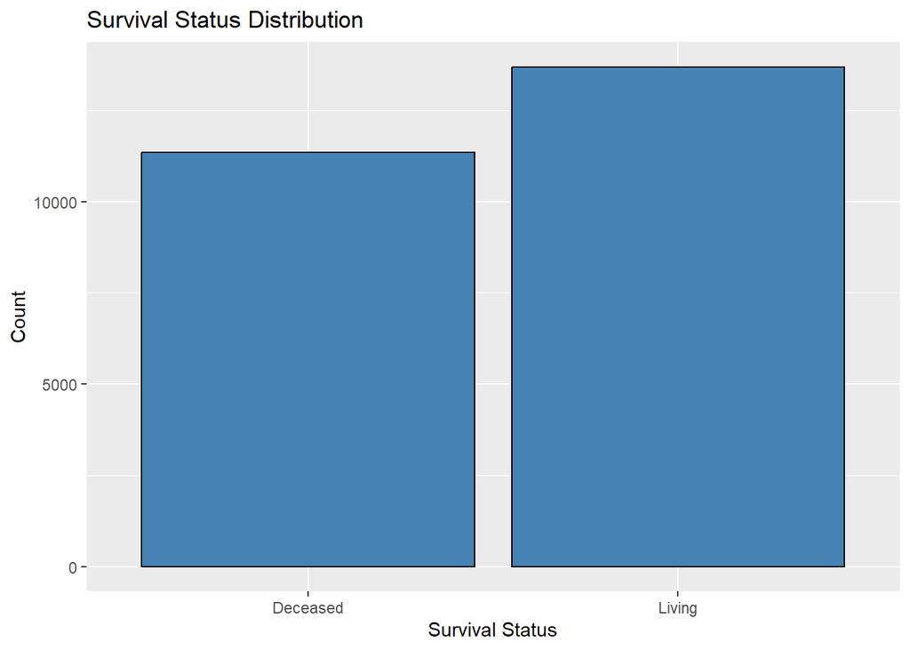

```r
ggplot(clinical_clean, aes(x = overall_survival_status)) +
  geom_bar(fill = "steelblue" , color = "black") +
  labs(
    title = "Survival Status Distribution",
    x = "Survival Status",
    y = "Count"
  )
```

The majority of patients are categorized as living or deceased,providing an overview of outcome distribution within the data set.

## Step 3.12: Survival months distribution

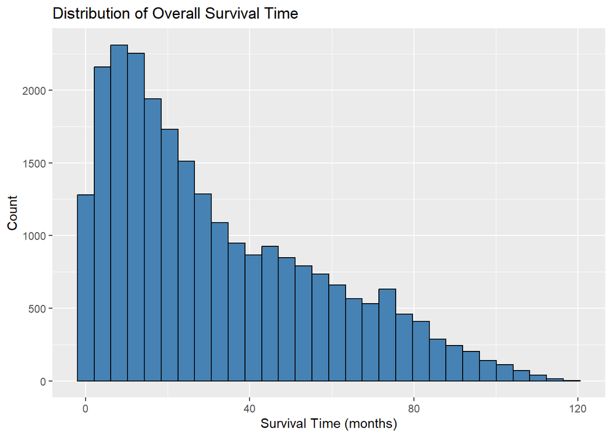

```r
ggplot(clinical_clean, aes(x = overall_survival_months)) +
  geom_histogram(bins = 30, fill = "steelblue", color = "black") +
  labs(
    title = "Distribution of Overall Survival Time",
    x = "Survival Time (months)",
    y = "Count"
  )
```

The survival time distribution shows variability in patient outcomes,with a higher concentration of cases at lower survival durations.

## Step 3.13: Survival time by survival status

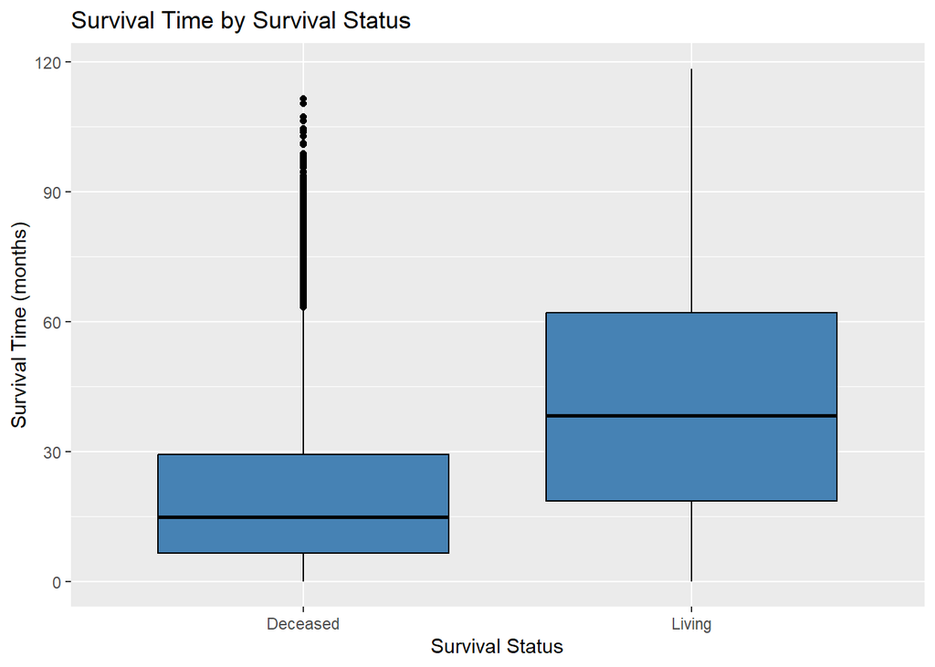

```r
ggplot(clinical_clean, aes(
  x = overall_survival_status,
  y = overall_survival_months
)) +
  geom_boxplot(fill = "steelblue" , color = "black") +
  labs(
    title = "Survival Time by Survival Status",
    x = "Survival Status",
    y = "Survival Time (months)"
  )
```

This box plot compares survival times between living and deceased patients,highlighting differences in outcome distributions.

## Step 3.14: Survival status vs cancer stage

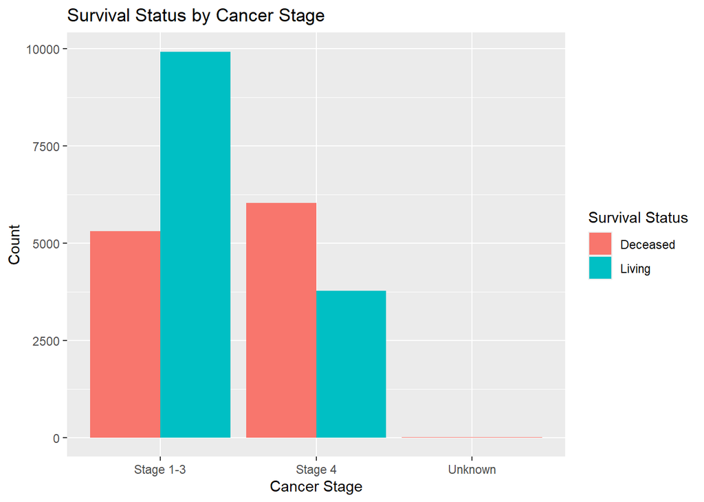

```r
ggplot(clinical_clean, aes(
  x = stage_highest_recorded,
  fill = overall_survival_status
)) +
  geom_bar(position = "dodge") +
  labs(
    title = "Survival Status by Cancer Stage",
    x = "Cancer Stage",
    y = "Count",
    fill = "Survival Status"
  )
```

The relationship between cancer stage and survival status indicates variation in outcomes across different disease stages.

**EDA Summary** Overall, exploratory analysis revealed meaningful patterns in patient demographics,clinical characteristics, and survival outcomes. These findings guide further analysis and interpretation. ————————————————————————————————————— # Step 4: Interpretation

**Descriptive Insights from EDA**

## Step 4.1: Cancer stage distribution

The distribution of cancer stages shows that early to mid-stage cases are more frequently represented in the data set, while advanced stages appear less often.This suggests that the data set contains a larger proportion of patients diagnosed before reaching late-stage disease.

## Step 4.2: Primary tumor site distribution

Analysis of primary tumor sites indicates that certain anatomical locations are more commonly affected than others. This uneven distribution reflects variation in cancer occurrence across different tumor sites within the data set.

## Step 4.3: Survival status distribution

The survival status distribution shows the proportion of patients categorized as living or deceased. Both outcome groups are well represented, providing a balanced overview of patient outcomes for exploratory analysis.

Overall, the descriptive insights highlight key characteristics of the data set,including stage prevalence, common tumor sites, and outcome representation.These observations form the basis for further relationship-based interpretation.

**Relationship-Based Interpretation**

## Step 4.4: Cancer Stage vs Survival Status

The relationship between cancer stage and survival status shows that patients diagnosed at earlier stages (Stage 1–3) have better survival outcomes compared to those diagnosed at Stage 4. Advanced-stage cancer is associated with higher mortality, highlighting the impact of disease progression on patient outcomes.

## Step 4.5: Primary Tumor Site and Outcomes

Certain primary tumor sites are more frequently represented in the data set, such as lung and breast. Differences in tumor site prevalence may contribute to variation in survival outcomes, as prognosis and treatment response often depend on tumor origin.

**Relationship between Cancer Stage and Survival Status**

The comparison between cancer stage and survival status indicates a clear pattern in patient outcomes. Early to mid-stage cases show a higher proportion of living patients, whereas advanced-stage cases are associated with a greater number of deceased outcomes. This suggests that disease stage plays an important role in survival.

The observed trend aligns with clinical expectations, where earlier diagnosis is generally linked to better prognosis. Although this analysis is descriptive, it highlights a meaningful relationship between cancer progression and patient survival.

Overall, this relationship-based insight complements the earlier uni variate findings and strengthens the exploratory understanding of outcome patterns within the data set.

**Overall Interpretation**

# Next Phase

This section discusses the findings from the exploratory analysis in relation to the chosen analytical question _______________________________________________________________________________________________________________

# Step 5: Analytical Interpretation

## Step 5.1: Loading the cleaned Dataset

```r
cancer_data <- read.csv(
  here("data" , "clean" , "clinical_data_clean.csv")
)
```

## Step 5.2: View basic structure

```r
glimpse(cancer_data)
```

```
## Rows: 25,040
## Columns: 11
## $ study_id                <chr> "msk_chord_2024", "msk_chord_2024", "msk_chord…
## $ patient_id              <chr> "P-0000012", "P-0000012", "P-0000015", "P-0000…
## $ sample_id               <chr> "P-0000012-T02-IM3", "P-0000012-T03-IM3", "P-0…
## $ current_age             <int> 68, 68, 45, 68, 53, 43, 54, 71, 83, 50, 70, 46…
## $ sex                     <chr> "Female", "Female", "Female", "Female", "Femal…
## $ race                    <chr> "White", "White", "White", "Other", "White", "…
## $ cancer_type             <chr> "Breast Cancer", "Non-Small Cell Lung Cancer",…
## $ primary_tumor_site      <chr> "Breast", "Lung", "Breast", "Lung", "Breast", …
## $ stage_highest_recorded  <chr> "Stage 1-3", "Stage 1-3", "Stage 1-3", "Stage …
## $ overall_survival_months <dbl> 118.4546647, 118.4546647, 13.9068341, 115.4628…
## $ overall_survival_status <chr> "Living", "Living", "Deceased", "Living", "Dec…
```

The cleaned data set generated during the data preparation phase is loaded for future analysis.This ensures consistency and avoids repeating data cleaning steps.

## Step 5.3: Feature Preparation

```r
# select relevant demographic and clinical variable for analysis
cancer_data <- cancer_data %>%
  select(
   current_age,
    sex,
    cancer_type,
    stage_highest_recorded,
    overall_survival_status
  )
```

```r
# Convert Gender to factor
cancer_data$sex <- as.factor(cancer_data$sex)
```

```r
# Convert stage highest recorded to ordered factor
cancer_data$stage_highest_recorded <- factor(
  cancer_data$stage_highest_recorded,
  ordered = TRUE
)

cancer_data$cancer_type <- as.factor(cancer_data$cancer_type)

cancer_data$overall_survival_status <- as.factor(
  cancer_data$overall_survival_status
)
```

```r
# Check missing values
colSums(is.na(cancer_data))
```

```
##             current_age                     sex             cancer_type
##                       0                       0                       0
##  stage_highest_recorded overall_survival_status
##                       0                       0
```

Relevant demographic and clinical variables were selected for analytical interpretation. Categorical variables were converted to factors to enable grouped comparisons. No further cleaning was required at this stage. _______________________________________________________________________________________________________________ # Step 6: Relationship Between Patient Characteristics and Survival Outcome

## Step 6.1: Age vs Seravial Outcomes

```r
# Summary statistics for age by survival status
aggregate(
  current_age ~ overall_survival_status,
  data = cancer_data,
  FUN = function(x) c(mean = mean(x), median = median(x))
)
```

```
##   overall_survival_status current_age.mean current_age.median
## 1                Deceased         65.50441           67.00000
## 2                  Living         65.45399           67.00000
```

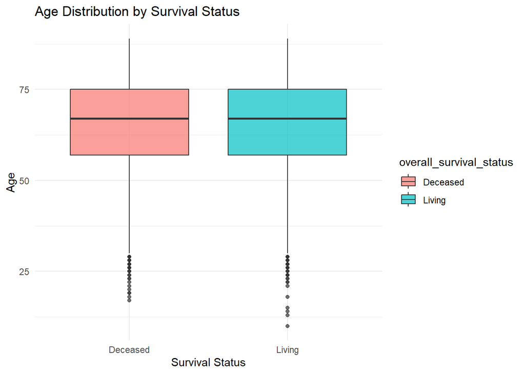

```r
# Box plot: Age vs Survival Status
ggplot(cancer_data, aes(x = overall_survival_status, y = current_age, fill = overall_survival_status)) +
  geom_boxplot(alpha = 0.7) +
  labs(
    title = "Age Distribution by Survival Status",
    x = "Survival Status",
    y = "Age"
  ) +
  theme_minimal()
```

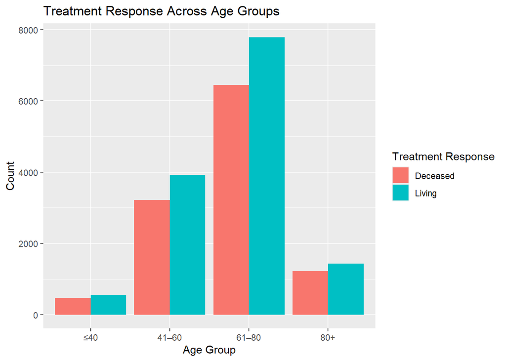

```r
# Create age groups for better visualization of the bar chart
cancer_data <- cancer_data %>%
  mutate(age_group = case_when(
    current_age <= 40 ~ "≤40",
    current_age <= 60 ~ "41–60",
    current_age <= 80 ~ "61–80",
    current_age > 80  ~ "80+",
    TRUE ~ "Unknown"
  )) %>%
  mutate(age_group = factor(age_group, levels = c("≤40", "41–60", "61–80", "80+")))

ggplot(cancer_data, aes(x = age_group, fill = overall_survival_status)) +
  geom_bar(position = "dodge") +
  labs(
    title = "Treatment Response Across Age Groups",
    x = "Age Group",
    y = "Count",
    fill = "Treatment Response"
  )
```

This bar chart categorizes patients into life stages to visualize the volume of outcomes. While the box plot showed the age range, this reveals that the 61–80 group is the most represented, allowing us to see how mortality counts scale with the population size in each bracket.

## Step 6.2: Sex vs Survival Outcomes

```r
# Sex distribution by survival status
table(cancer_data$sex, cancer_data$overall_survival_status)
```

```
##
##           Deceased Living
##   Female      6069   7854
##   Male        5274   5840
##   Unknown        3      0
```

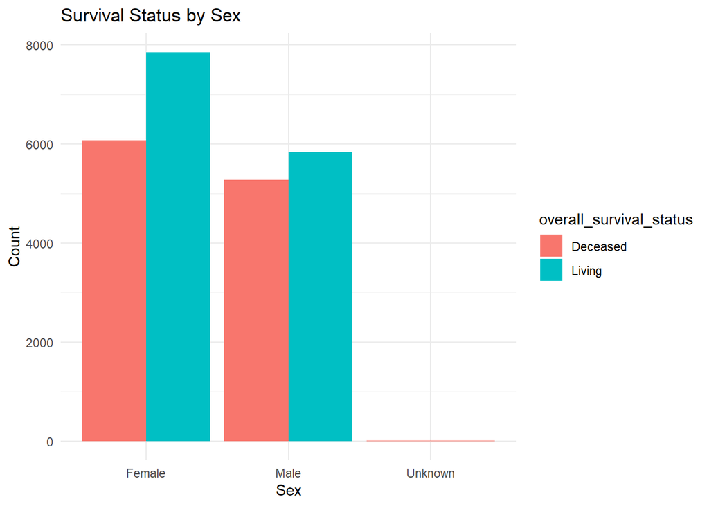

```r
# Bar chart: Sex vs Survival Status
ggplot(cancer_data, aes(x = sex, fill = overall_survival_status)) +
  geom_bar(position = "dodge") +
  labs(
    title = "Survival Status by Sex",
    x = "Sex",
    y = "Count"
  ) +
  theme_minimal()
```

Survival distribution appears relatively similar between sexes. Sex feature alone does not show a strong difference in survival outcome.

## Step 6.3: Tumor Stage vs Suraival Outcomes

```r
# Tumor stage vs survival status table
table(cancer_data$stage_highest_recorded,
      cancer_data$overall_survival_status)
```

```
##
##             Deceased Living
##   Stage 1-3     5303   9926
##   Stage 4       6040   3768
##   Unknown          3      0
```

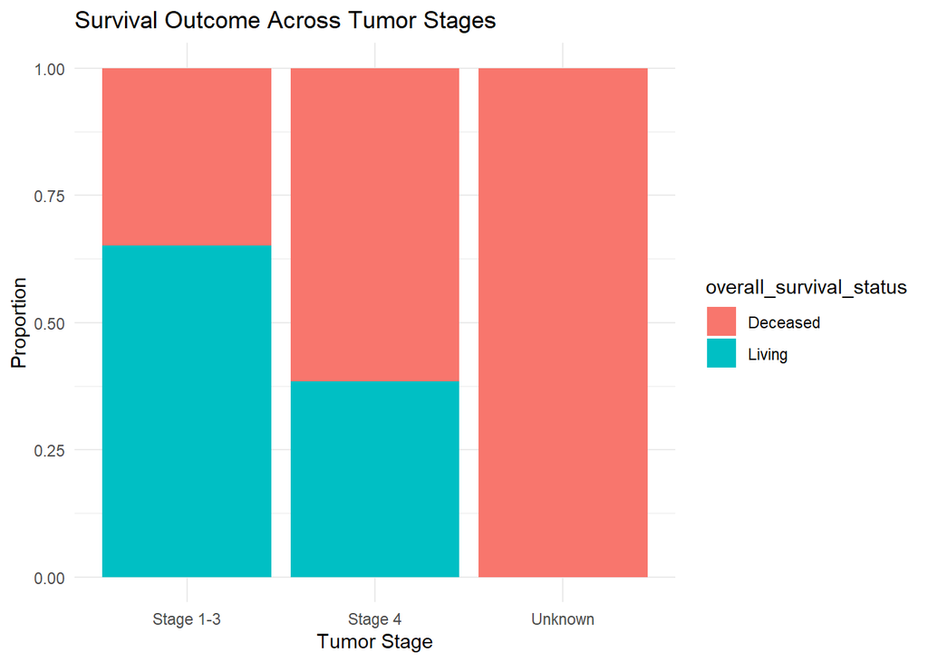

```r
# Stacked proportion bar chart
ggplot(cancer_data,
       aes(x = stage_highest_recorded,
           fill = overall_survival_status)) +
  geom_bar(position = "fill") +
  labs(
    title = "Survival Outcome Across Tumor Stages",
    x = "Tumor Stage",
    y = "Proportion"
  ) +
  theme_minimal()
```

Advanced tumor stages show a higher proportion of deceased patients. Earlier stages are associated with improved survival outcomes.

## Step 6.4: Cancer Type vs Survival Outcomes

```r
# Cancer type vs survival status table
table(cancer_data$cancer_type,
      cancer_data$overall_survival_status)
```

```
##
##                              Deceased Living
##   Breast Cancer                  1990   3378
##   Colorectal Cancer              2220   3323
##   Non-Small Cell Lung Cancer     3975   3834
##   Pancreatic Cancer              2120    989
##   Prostate Cancer                1041   2170
```

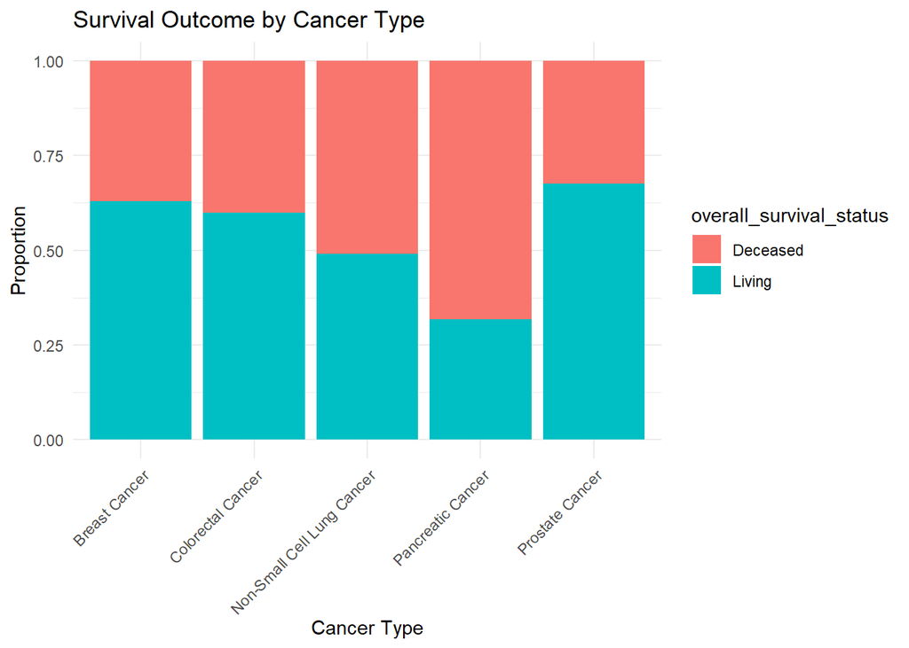

```r
# Proportion plot
ggplot(cancer_data,
       aes(x = cancer_type,
           fill = overall_survival_status)) +
  geom_bar(position = "fill") +
  labs(
    title = "Survival Outcome by Cancer Type",
    x = "Cancer Type",
    y = "Proportion"
  ) +
  theme_minimal() +
  theme(axis.text.x = element_text(angle = 45, hjust = 1))
```

Survival outcomes differ across cancer types. Certain cancer categories demonstrate higher mortality proportions

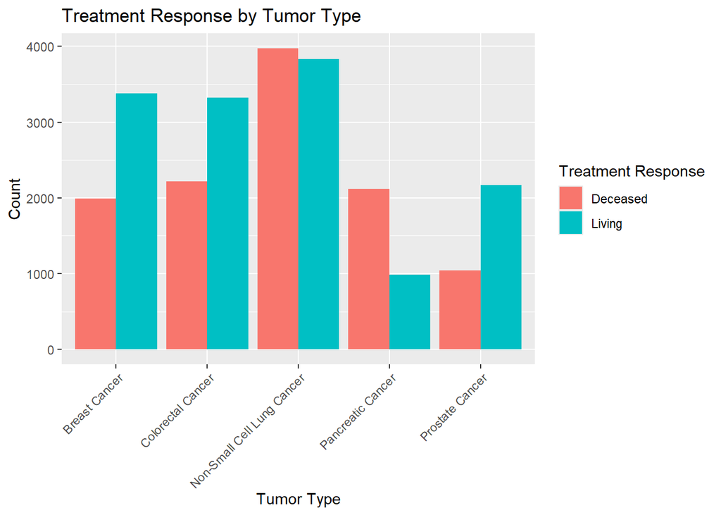

```r
target_cancers <- c("Breast Cancer", "Colorectal Cancer",
                    "Non-Small Cell Lung Cancer", "Pancreatic Cancer", "Prostate Cancer")

cancer_data_sub <- cancer_data %>%
  filter(cancer_type %in% target_cancers)

ggplot(cancer_data_sub, aes(x = cancer_type, fill = overall_survival_status)) +
  geom_bar(position = "dodge") +
  labs(
    title = "Treatment Response by Tumor Type",
    x = "Tumor Type",
    y = "Count",
    fill = "Treatment Response"
  ) +
  theme(axis.text.x = element_text(angle = 45, hjust = 1))
```

This plot shows the actual frequency of survival outcomes for the most common cancer types. It highlights that while Lung Cancer has the highest volume, Pancreatic Cancer shows a noticeably higher count of deceased patients compared to living ones, providing a clearer view of clinical severity than proportions alone.

**Interpretation Summary**

**Answer to the Analytical Question**

Question: Can basic patient demographics (age, gender) and clinical features (tumor type, stage) be used to understand primary treatment response?